# Preparing data

Xu Liu

# 1 Saving and loading R objects

- R allows us to save and load R data objects to external files.

## 1.1 Saving objects with `save()`

- The simplest way to save an object is with the function `save`.

```r
  My_data <- read.csv("studentgrades.csv", header = TRUE)
```

```r
 save(My_data, file="My_data.RData")
```

## 1.2 Loading data with `load()`

- Now, we can easily load this object back into R with the function `load`

```r
 rm('My_data')
 load("My_data.RData")
 My_data
```

| StudentID | First | Last | Math | Science | Social.Studies |
| --- | --- | --- | --- | --- | --- |
| 11 | Bob | Smith | 90 | 80 | 67 |
| 12 | Jane | Weary | 75 | NA | 80 |
| 10 | Dan | Thornton | 65 | 75 | 70 |
| 40 | Mary | O’Leary | 90 | 95 | 92 |

- We can save and load variables as follows.

```r
 x <- runif(20)
 y <- list(a = 1, b = TRUE, c = "oops")
 save(x, y, file = "xy.RData")
 rm('x')
 rm('y')
 load('xy.RData')
 x
```

```
##  [1] 0.42872105 0.60667648 0.04343634 0.77761082 0.49699601 0.58876900
##  [7] 0.69749981 0.16832778 0.59985822 0.69661858 0.38214905 0.56301265
## [13] 0.59091740 0.99918827 0.46933250 0.27585323 0.93890536 0.06592883
## [19] 0.14667353 0.47795312
```

```r
 y
```

```
## $a
## [1] 1
##
## $b
## [1] TRUE
##
## $c
## [1] "oops"
```

- We can save and load functions as follows.

```r
 add_square <- function(x, y) return((x + y )^2)
 save(add_square, file='myadd_square_function.Rdata')
 rm('add_square')
 load('myadd_square_function.Rdata')
 add_square(1, 2)
```

```
## [1] 9
```

```r
 add_square(10, 5)
```

```
## [1] 225
```

# 2 Combing datasets

- Let’s start with one of the most common obstacles to data analysis: working with data that’s stored in two different places. This section discusses several tools in R used for combining data sets.

## 2.1 Pasting together data structures

- R provides several functions that allow you to paste together multiple data structures into a single structure.

### 2.1.1 `paste`

- The simplest of these functions is `paste`. The `paste` function allows you to concatenate multiple character vectors into a single vector. For more information on `paste`, please see the help file.

```r
 ?paste
```

```r
 x <- c('a', 'b', 'c', 'd', 'e')
 y <- c('A', 'B', 'C', 'D', 'E')
 paste(x, y)
```

```
## [1] "a A" "b B" "c C" "d D" "e E"
```

- By default, values are separated by a space; you can specify another separator (or none at all) with the `sep` argument:

```r
 paste(x, y, sep='_')
```

```
## [1] "a_A" "b_B" "c_C" "d_D" "e_E"
```

- If you would like all of the values in the returned vector to be concatenated with each other (to return just a single value), then specify a value for the `collapse` argument. The value of collapse will be used as the separator in this value:

```r
 paste(x, y, sep='-', collapse = '_')
```

```
## [1] "a-A_b-B_c-C_d-D_e-E"
```

### 2.1.2 `rbind` and `cbind`

- Sometimes, we would like to bind together multiple data frames or matrices. We can do this with the `rbind` and `cbind` functions.
- The `cbind` function will combine objects by adding columns. let’s start with the matrix.

```r
 A <- matrix(rnorm(12), 4, 3)
 B <- matrix(rnorm(8), 4, 2)
 A
```

```
##            [,1]      [,2]       [,3]
## [1,]  0.5750867  1.483409 -0.8729875
## [2,] -1.8740441 -1.966150  0.3645746
## [3,]  0.3842797  1.192968  0.4623019
## [4,]  1.1064848  2.087169 -1.2398803
```

```r
 B
```

```
##            [,1]       [,2]
## [1,] -0.9726710 -0.8418112
## [2,] -0.9176559 -0.7047176
## [3,]  1.0523675 -0.4254123
## [4,] -1.0292503  0.3892591
```

```r
 cbind(A, B)
```

```
##            [,1]      [,2]       [,3]       [,4]       [,5]
## [1,]  0.5750867  1.483409 -0.8729875 -0.9726710 -0.8418112
## [2,] -1.8740441 -1.966150  0.3645746 -0.9176559 -0.7047176
## [3,]  0.3842797  1.192968  0.4623019  1.0523675 -0.4254123
## [4,]  1.1064848  2.087169 -1.2398803 -1.0292503  0.3892591
```

Then, for the data frame.

```r
grades <- read.csv("studentgrades.csv", header = TRUE)
grades
```

| StudentID | First | Last | Math | Science | Social.Studies |
| --- | --- | --- | --- | --- | --- |
| 11 | Bob | Smith | 90 | 80 | 67 |
| 12 | Jane | Weary | 75 | NA | 80 |
| 10 | Dan | Thornton | 65 | 75 | 70 |
| 40 | Mary | O’Leary | 90 | 95 | 92 |

Now, let’s create a new data frame with two more columns

```r
 Chinese  <- c(73, 82, 90, 68)
 English <- c(89, 97, 82, 86)
 more.cols <- data.frame(Chinese, English)
 more.cols
```

| Chinese | English |
| --- | --- |
| 73 | 89 |
| 82 | 97 |
| 90 | 82 |
| 68 | 86 |

Finally, let’s put together these two data frames:

```r
 Grades <- cbind(grades, more.cols)
 Grades
```

| StudentID | First | Last | Math | Science | Social.Studies | Chinese | English |
| --- | --- | --- | --- | --- | --- | --- | --- |
| 11 | Bob | Smith | 90 | 80 | 67 | 73 | 89 |
| 12 | Jane | Weary | 75 | NA | 80 | 82 | 97 |
| 10 | Dan | Thornton | 65 | 75 | 70 | 90 | 82 |
| 40 | Mary | O’Leary | 90 | 95 | 92 | 68 | 86 |

- The `rbind` function will combine objects by adding *rows*. We can picture this as combining two tables vertically. For the matrix,

```r
 A <- matrix(rnorm(16), 4, 4)
 B <- matrix(rnorm(12), 3, 4)
 A
```

```
##            [,1]      [,2]       [,3]       [,4]
## [1,] -0.6800206 0.3129961 -1.6470310  0.4876048
## [2,] -1.3049666 0.4789635 -0.6016342 -0.4401903
## [3,] -1.6451458 0.6233991  0.3725783 -1.7780730
## [4,] -1.1572684 1.0998613  0.3528149  0.2917322
```

```r
 B
```

```
##            [,1]       [,2]       [,3]       [,4]
## [1,]  1.5221356  0.5455718 -0.2560096 -1.5297287
## [2,] -0.5258189 -1.5839013 -0.6406959 -1.6194910
## [3,] -0.1384319  0.9207622 -2.4610803 -0.4031037
```

```r
 rbind(A, B)
```

```
##            [,1]       [,2]       [,3]       [,4]
## [1,] -0.6800206  0.3129961 -1.6470310  0.4876048
## [2,] -1.3049666  0.4789635 -0.6016342 -0.4401903
## [3,] -1.6451458  0.6233991  0.3725783 -1.7780730
## [4,] -1.1572684  1.0998613  0.3528149  0.2917322
## [5,]  1.5221356  0.5455718 -0.2560096 -1.5297287
## [6,] -0.5258189 -1.5839013 -0.6406959 -1.6194910
## [7,] -0.1384319  0.9207622 -2.4610803 -0.4031037
```

For the data frame, let’s create a new data frame with two more rows

```r
 StudentID <- c(43, 52)
 First <- c('Ming', 'Qiang')
 Last <- c('Li', 'Zhang')
 Math <- c(93, 87)
 Science <- c(84, 93)
 Social.Studies <- c(71, 88)
 Chinese <- c(98, 96)
 English <- c(73, 80)
 more.rows <- data.frame(StudentID, First, Last, Math, Science,
                         Social.Studies, Chinese, English)
 more.rows
```

| StudentID | First | Last | Math | Science | Social.Studies | Chinese | English |
| --- | --- | --- | --- | --- | --- | --- | --- |
| 43 | Ming | Li | 93 | 84 | 71 | 98 | 73 |
| 52 | Qiang | Zhang | 87 | 93 | 88 | 96 | 80 |

```r
 rbind(Grades, more.rows)
```

| StudentID | First | Last | Math | Science | Social.Studies | Chinese | English |
| --- | --- | --- | --- | --- | --- | --- | --- |
| 11 | Bob | Smith | 90 | 80 | 67 | 73 | 89 |
| 12 | Jane | Weary | 75 | NA | 80 | 82 | 97 |
| 10 | Dan | Thornton | 65 | 75 | 70 | 90 | 82 |
| 40 | Mary | O’Leary | 90 | 95 | 92 | 68 | 86 |
| 43 | Ming | Li | 93 | 84 | 71 | 98 | 73 |
| 52 | Qiang | Zhang | 87 | 93 | 88 | 96 | 80 |

### 2.1.3 `merge`

- Generally, the safest and most efective way to merge two data sets together is with the `merge` command. More information can be found by

```r
 ?merge
```

For example

```r
 x <- data.frame(k1 = c(NA,NA,3,7,9), k2 = c(1,2,3,4,11))
 y <- data.frame(k2 = c(1,2,3,4,12), k3 = c(NA,4,NA,6,8))
 x
```

| k1 | k2 |
| --- | --- |
| NA | 1 |
| NA | 2 |
| 3 | 3 |
| 7 | 4 |
| 9 | 11 |

```r
 y
```

| k2 | k3 |
| --- | --- |
| 1 | NA |
| 2 | 4 |
| 3 | NA |
| 4 | 6 |
| 12 | 8 |

```r
 merge(x, y)
```

| k2 | k1 | k3 |
| --- | --- | --- |
| 1 | NA | NA |
| 2 | NA | 4 |
| 3 | 3 | NA |
| 4 | 7 | 6 |

```r
 merge(x, y, all.x = T)
```

| k2 | k1 | k3 |
| --- | --- | --- |
| 1 | NA | NA |
| 2 | NA | 4 |
| 3 | 3 | NA |
| 4 | 7 | 6 |
| 11 | 9 | NA |

```r
 merge(x, y, all.y = T)
```

| k2 | k1 | k3 |
| --- | --- | --- |
| 1 | NA | NA |
| 2 | NA | 4 |
| 3 | 3 | NA |
| 4 | 7 | 6 |
| 12 | NA | 8 |

```r
 merge(x, y, all = T)
```

| k2 | k1 | k3 |
| --- | --- | --- |
| 1 | NA | NA |
| 2 | NA | 4 |
| 3 | 3 | NA |
| 4 | 7 | 6 |
| 11 | 9 | NA |
| 12 | NA | 8 |

```r
 x <- data.frame(k1 = c(NA,NA,3,4,5), k2 = c(1,NA,NA,4,5), data = 1:5)
 y <- data.frame(k1 = c(NA,2,NA,4,5), k2 = c(NA,NA,3,4,5), data = 1:5)
 x
```

| k1 | k2 | data |
| --- | --- | --- |
| NA | 1 | 1 |
| NA | NA | 2 |
| 3 | NA | 3 |
| 4 | 4 | 4 |
| 5 | 5 | 5 |

```r
 y
```

| k1 | k2 | data |
| --- | --- | --- |
| NA | NA | 1 |
| 2 | NA | 2 |
| NA | 3 | 3 |
| 4 | 4 | 4 |
| 5 | 5 | 5 |

```r
 merge(x, y, by = c("k1","k2")) # NA's match
```

| k1 | k2 | data.x | data.y |
| --- | --- | --- | --- |
| 4 | 4 | 4 | 4 |
| 5 | 5 | 5 | 5 |
| NA | NA | 2 | 1 |

```r
 merge(x, y, by = "k1") # NA's match, so 6 rows
```

| k1 | k2.x | data.x | k2.y | data.y |
| --- | --- | --- | --- | --- |
| 4 | 4 | 4 | 4 | 4 |
| 5 | 5 | 5 | 5 | 5 |
| NA | 1 | 1 | NA | 1 |
| NA | 1 | 1 | 3 | 3 |
| NA | NA | 2 | NA | 1 |
| NA | NA | 2 | 3 | 3 |

```r
 merge(x, y, by = "k2") # NA's match, so 6 rows
```

| k2 | k1.x | data.x | k1.y | data.y |
| --- | --- | --- | --- | --- |
| 4 | 4 | 4 | 4 | 4 |
| 5 | 5 | 5 | 5 | 5 |
| NA | NA | 2 | NA | 1 |
| NA | NA | 2 | 2 | 2 |
| NA | 3 | 3 | NA | 1 |
| NA | 3 | 3 | 2 | 2 |

```r
 merge(x, y, by = "k2", incomparables = NA) # 2 rows
```

| k2 | k1.x | data.x | k1.y | data.y |
| --- | --- | --- | --- | --- |
| 4 | 4 | 4 | 4 | 4 |
| 5 | 5 | 5 | 5 | 5 |

## 2.2 Usefule functions for strings

- Whereas mathematical and statistical functions operate on numerical data, character functions extract information from textual data or reformat textual data for printing and reporting. For example, we may want to concatenate a person’s first name and last name, ensuring that the first letter of each is capitalized. Here are some of the most useful character functions.
- `nchar(x)` :
  - Counts the number of characters of *x*.

```r
 nchar('123456abc')
```

```
## [1] 9
```

```r
 x <- c("ab", "cde", "fghij")
 length(x)
```

```
## [1] 3
```

```r
 nchar(x[3])
```

```
## [1] 5
```

- `substr(x, start, stop)`:
  - Extracts or replaces substrings in a character vector.

```r
 x <- "abcdef"
 substr(x, 2, 4)
```

```
## [1] "bcd"
```

```r
 substr(x, 2, 4) <- "22222"
 x
```

```
## [1] "a222ef"
```

- `grep(pattern, x, ignore.case=FALSE, fixed=FALSE)`:
  - Searches for pattern in *x*. If *fixed=FALSE*, then *pattern* is a regular expression. If *fixed=TRUE*, then *pattern* is a text string. Returns the matching indices.

```r
 grep("A", c("b","A","c"), fixed=TRUE)
```

```
## [1] 2
```

```r
 #letters
 grep("[a-z]", letters)
```

```
##  [1]  1  2  3  4  5  6  7  8  9 10 11 12 13 14 15 16 17 18 19 20 21 22 23
## [24] 24 25 26
```

- `sub(pattern, replacement, x, ignore.case=FALSE, fixed=FALSE)`:
  - Finds *pattern* in *x* and substitutes the *replacement* text. If *fixed=FALSE*, then *pattern* is a regular expression. If *fixed=TRUE*, then *pattern* is a text string.
- and `gsub(pattern, replacement, x, ignore.case=FALSE, fixed=FALSE)

```r
sub("\\s",".","Hello There")
```

```
## [1] "Hello.There"
```

```r
sub(" ",".","Hello There")
```

```
## [1] "Hello.There"
```

```r
sub("."," ",sub("\\s",".","Hello There"),fixed = TRUE)
```

```
## [1] "Hello There"
```

```r
gsub("\\s",".","Hello World There")
```

```
## [1] "Hello.World.There"
```

```r
gsub(" ",".","Hello World There")
```

```
## [1] "Hello.World.There"
```

```r
gsub("."," ",gsub("\\s",".","Hello Word There"),fixed = TRUE)
```

```
## [1] "Hello Word There"
```

[output not shown]

- `strsplit(x, split, fixed=FALSE)`:
  - Splits the elements of character vector `x` at *split*. If *fixed=FALSE*, then *pattern* is a regular *expression*. If *fixed=TRUE*, then *pattern* is a text string.

```r
 strsplit("abc", "")
```

```
## [[1]]
## [1] "a" "b" "c"
```

- `chartr(old, new, x)`:
  - Translates each character in `x` that is specified in `old` to the corresponding character specified in `new`. Ranges are supported in the specifications, but character classes and repeated characters are not. If `old` contains more characters than `new`, an error is signaled; if it contains fewer characters, the extra characters at the end of `new` are ignored.

```r
x <- "Hello World there"
chartr("the", " He", x)
```

```
## [1] "Hello World  Here"
```

```r
chartr("Th", "th", x)
```

```
## [1] "Hello World there"
```

```r
chartr("th", "Th", x)
```

```
## [1] "Hello World There"
```

- `toupper(x)` :
  - Uppercase.

```r
 toupper("abc")
```

```
## [1] "ABC"
```

- `tolower(x)`:
  - Lowercase.

```r
 tolower("ABC")
```

```
## [1] "abc"
```

# 3 Transformations

## 3.1 Some useful transformation functions

- Sometimes a variable will have the wrong type. For example, a numeric variable may be incorrectly made a character string when a data set is imported from Excel. You can change variables’ types with a number of commands.

| Function | Purpose |
| --- | --- |
| as.factor | coerces its argument to a *factor*. |
| as.numeric | attempts to turn its argument into *numeric*. |
| as.matrix | attempts to turn its argument into a *matrix*. |
| as.data.frame | coerce it into a *data.frame*. |

```r
 x <- c(1, 1, 2, 2, 2, 3, 3)
 class(x)
```

```
## [1] "numeric"
```

```r
 y <- as.factor(x)
 class(y)
```

```
## [1] "factor"
```

```r
z <- as.numeric(y)
z
```

```
## [1] 1 1 2 2 2 3 3
```

```r
class(z)
```

```
## [1] "numeric"
```

```r
 Chinese  <- c(73, 82, 90, 68)
 English <- c(89, 97, 82, 86)
 my_data_1 <- data.frame(Chinese, English)
 class(my_data_1)
```

```
## [1] "data.frame"
```

```r
 my_data_1
```

| Chinese | English |
| --- | --- |
| 73 | 89 |
| 82 | 97 |
| 90 | 82 |
| 68 | 86 |

```r
 my_data_2 <- as.matrix(my_data_1)
 class(my_data_2)
```

```
## [1] "matrix"
```

```r
 my_data_2
```

```
##      Chinese English
## [1,]      73      89
## [2,]      82      97
## [3,]      90      82
## [4,]      68      86
```

```r
 my_data_3 <- as.data.frame(my_data_2)
 class(my_data_3)
```

```
## [1] "data.frame"
```

```r
 my_data_3
```

| Chinese | English |
| --- | --- |
| 73 | 89 |
| 82 | 97 |
| 90 | 82 |
| 68 | 86 |

## 3.2 The function `transform`

- A convenient function for changing variables in a data frame is the transform function. Formally, the syntax of `transform` is

```r
transform(`_data`, ...)
```

Notice that there aren’t any named arguments for this function. To use `transform`, we specify a data frame (as the first argument) and a set of expressions that use variables within the data frame. The `transform` function applies each expression to the data frame and then returns the final data frame.

```r
 head(airquality)
```

| Ozone | Solar.R | Wind | Temp | Month | Day |
| --- | --- | --- | --- | --- | --- |
| 41 | 190 | 7.4 | 67 | 5 | 1 |
| 36 | 118 | 8.0 | 72 | 5 | 2 |
| 12 | 149 | 12.6 | 74 | 5 | 3 |
| 18 | 313 | 11.5 | 62 | 5 | 4 |
| NA | NA | 14.3 | 56 | 5 | 5 |
| 28 | NA | 14.9 | 66 | 5 | 6 |

```r
 NEW <- transform(airquality, new = -Ozone, Temp = (Temp-32)/1.8)
 head(NEW)
```

| Ozone | Solar.R | Wind | Temp | Month | Day | new |
| --- | --- | --- | --- | --- | --- | --- |
| 41 | 190 | 7.4 | 19.44444 | 5 | 1 | -41 |
| 36 | 118 | 8.0 | 22.22222 | 5 | 2 | -36 |
| 12 | 149 | 12.6 | 23.33333 | 5 | 3 | -12 |
| 18 | 313 | 11.5 | 16.66667 | 5 | 4 | -18 |
| NA | NA | 14.3 | 13.33333 | 5 | 5 | NA |
| 28 | NA | 14.9 | 18.88889 | 5 | 6 | -28 |

## 3.3 Applying a function to each element of an object

- When transforming data, one common operation is to apply a function to a set of objects (or each part of a composite object) and return a new set of objects (or a new composite object). The base R library includes a set of different functions for doing this.

### 3.3.1 Applying a function to an array

- To apply a function to parts of an array (or matrix), use the `apply` function:

```r
apply(X, MARGIN, FUN, ...)
```

`Apply` accepts three arguments: *X* is the array to which a function is applied, *FUN* is the function, and *MARGIN* specifies the dimensions to which we would like to apply a function. Optionally, we can specify arguments to *FUN* as addition arguments to apply arguments to *FUN*.) Here’s a simple example to show how this works.

```r
 x <- rnorm(20)
 dim(x) <- c(5,4)
 x
```

```
##            [,1]       [,2]       [,3]        [,4]
## [1,] -0.1722572  0.1283156  0.2593631  0.38021267
## [2,]  0.7606900 -0.3660551  0.7553124 -1.38121944
## [3,]  0.2686112 -0.6668906 -1.8518024  0.65494485
## [4,]  1.1949534 -1.2119232  0.4495720  0.09011726
## [5,]  2.0180621 -0.6925227  0.2752041  1.84210159
```

```r
 apply(X = x , MARGIN = 1, FUN = max)
```

```
## [1] 0.3802127 0.7606900 0.6549448 1.1949534 2.0180621
```

```r
 apply(X = x , MARGIN = 2, FUN = max)
```

```
## [1] 2.0180621 0.1283156 0.7553124 1.8421016
```

```r
 apply(x , 1, function(x) sum(x)/length(x) )
```

```
## [1]  0.14890854 -0.05781802 -0.39878423  0.13067987  0.86071127
```

```r
 apply(x , 2, function(x) sum(x)/length(x) )
```

```
## [1]  0.81401191 -0.56181520 -0.02247016  0.31723139
```

```r
 apply(x , 1, var)
```

```
## [1] 0.05642443 1.05917931 1.24630146 1.01286624 1.68598078
```

```r
 apply(x , 2, var)
```

```
## [1] 0.7169713 0.2413421 1.0855665 1.3448906
```

```r
 apply(x , 1, function(x) sum((x-mean(x))^2)/(length(x)-1) )
```

```
## [1] 0.05642443 1.05917931 1.24630146 1.01286624 1.68598078
```

```r
 apply(x , 2, function(x) sum((x-mean(x))^2)/(length(x)-1) )
```

```
## [1] 0.7169713 0.2413421 1.0855665 1.3448906
```

Consider the following three-dimensional array:

```r
 x <- 1:27
 dim(x) <- c(3,3,3)
 x
```

```
## , , 1
##
##      [,1] [,2] [,3]
## [1,]    1    4    7
## [2,]    2    5    8
## [3,]    3    6    9
##
## , , 2
##
##      [,1] [,2] [,3]
## [1,]   10   13   16
## [2,]   11   14   17
## [3,]   12   15   18
##
## , , 3
##
##      [,1] [,2] [,3]
## [1,]   19   22   25
## [2,]   20   23   26
## [3,]   21   24   27
```

```r
 apply(X=x, MARGIN=1, FUN=paste,collapse=",")
```

```
## [1] "1,4,7,10,13,16,19,22,25" "2,5,8,11,14,17,20,23,26"
## [3] "3,6,9,12,15,18,21,24,27"
```

```r
 apply(X=x, MARGIN=2, FUN=paste,collapse=",")
```

```
## [1] "1,2,3,10,11,12,19,20,21" "4,5,6,13,14,15,22,23,24"
## [3] "7,8,9,16,17,18,25,26,27"
```

```r
 apply(X=x, MARGIN=3, FUN=paste,collapse=",")
```

```
## [1] "1,2,3,4,5,6,7,8,9"          "10,11,12,13,14,15,16,17,18"
## [3] "19,20,21,22,23,24,25,26,27"
```

- Other useful functions are `colSums`, `rowSums`, `colMeans` and `rowMeans`. These functions are equivalent to use of `apply` with `FUN = mean` or `FUN = sum` with appropriate margins.

```r
 x <- rnorm(20)
 dim(x) <- c(5,4)
 apply(x , 1, sum)
```

```
## [1]  0.4162867  2.8209556  1.0353302  1.3544686 -0.5727775
```

```r
 rowSums(x)
```

```
## [1]  0.4162867  2.8209556  1.0353302  1.3544686 -0.5727775
```

```r
 apply(x , 2, sum)
```

```
## [1]  2.7959838  2.7201720  0.8091082 -1.2710004
```

```r
 colSums(x)
```

```
## [1]  2.7959838  2.7201720  0.8091082 -1.2710004
```

```r
 apply(x , 1, mean)
```

```
## [1]  0.1040717  0.7052389  0.2588325  0.3386172 -0.1431944
```

```r
 rowMeans(x)
```

```
## [1]  0.1040717  0.7052389  0.2588325  0.3386172 -0.1431944
```

```r
 apply(x , 2, mean)
```

```
## [1]  0.5591968  0.5440344  0.1618216 -0.2542001
```

```r
 colMeans(x)
```

```
## [1]  0.5591968  0.5440344  0.1618216 -0.2542001
```

### 3.3.2 Applying a function to a list or vector

- To apply a function to each element in a vector or a list and return a list, we can use the function `lapply`. The function `lapply` requires two arguments: an object *X* and a function *FUNC*. (We may specify additional arguments that will be passed to *FUNC*.) Let’s look at a simple example of how to use `lapply`:

```r
 x <- as.list(1:5)
 lapply(x, function(x) 2^x)
```

```
## [[1]]
## [1] 2
##
## [[2]]
## [1] 4
##
## [[3]]
## [1] 8
##
## [[4]]
## [1] 16
##
## [[5]]
## [1] 32
```

- We can apply a function to a *data frame*, and the function will be applied to each vector in the *data frame*.

```r
 d <- data.frame(x=1:5, y=6:10)
 d
```

| x | y |
| --- | --- |
| 1 | 6 |
| 2 | 7 |
| 3 | 8 |
| 4 | 9 |
| 5 | 10 |

```r
lapply(d, function(x) 2^x)
```

```
## $x
## [1]  2  4  8 16 32
##
## $y
## [1]   64  128  256  512 1024
```

```r
 lapply(d, max)
```

```
## $x
## [1] 5
##
## $y
## [1] 10
```

```r
 lapply(d, mean)
```

```
## $x
## [1] 3
##
## $y
## [1] 8
```

- Sometimes, we might prefer to get a vector, matrix, or array instead of a list. To do this, we can use the `sapply` function. This function works exactly the same way as `apply`, except that it returns a vector or matrix (when appropriate):

```r
 d <- data.frame(x=1:5, y=6:10)
 sapply(d, function(x) 2^x)
```

```
##       x    y
## [1,]  2   64
## [2,]  4  128
## [3,]  8  256
## [4,] 16  512
## [5,] 32 1024
```

```r
 d <- data.frame(x=1:5, y=6:10)
 sapply(d, mean)
```

```
## x y
## 3 8
```

- Another related function is `vapply`. `vapply` is similar to `sapply`, but has a pre-specified type of return value, so it can be safer (and sometimes faster) to use.

```r
 i39 <- sapply(3:9, seq)
 i39
```

```
## [[1]]
## [1] 1 2 3
##
## [[2]]
## [1] 1 2 3 4
##
## [[3]]
## [1] 1 2 3 4 5
##
## [[4]]
## [1] 1 2 3 4 5 6
##
## [[5]]
## [1] 1 2 3 4 5 6 7
##
## [[6]]
## [1] 1 2 3 4 5 6 7 8
##
## [[7]]
## [1] 1 2 3 4 5 6 7 8 9
```

```r
 sapply(i39, fivenum)
```

```
##      [,1] [,2] [,3] [,4] [,5] [,6] [,7]
## [1,]  1.0  1.0    1  1.0  1.0  1.0    1
## [2,]  1.5  1.5    2  2.0  2.5  2.5    3
## [3,]  2.0  2.5    3  3.5  4.0  4.5    5
## [4,]  2.5  3.5    4  5.0  5.5  6.5    7
## [5,]  3.0  4.0    5  6.0  7.0  8.0    9
```

```r
 vapply(i39, fivenum,
       c(Min. = 0, "1st Qu." = 0, Median = 0, "3rd Qu." = 0, Max. = 0))
```

```
##         [,1] [,2] [,3] [,4] [,5] [,6] [,7]
## Min.     1.0  1.0    1  1.0  1.0  1.0    1
## 1st Qu.  1.5  1.5    2  2.0  2.5  2.5    3
## Median   2.0  2.5    3  3.5  4.0  4.5    5
## 3rd Qu.  2.5  3.5    4  5.0  5.5  6.5    7
## Max.     3.0  4.0    5  6.0  7.0  8.0    9
```

```r
x <- data.frame(cbind(x1=3, x2=c(2:1,4:5)))
x
```

| x1 | x2 |
| --- | --- |
| 3 | 2 |
| 3 | 1 |
| 3 | 4 |
| 3 | 5 |

```r
sapply(x, cumsum)
```

```
##      x1 x2
## [1,]  3  2
## [2,]  6  3
## [3,]  9  7
## [4,] 12 12
```

```r
vapply(x,cumsum,FUN.VALUE=c('a'=0,'b'=0,'c'=0,'d'=0))
```

```
##   x1 x2
## a  3  2
## b  6  3
## c  9  7
## d 12 12
```

- Another related function is `mapply`, the “multivariate”" version of sapply:

```r
mapply(FUN, ..., MoreArgs = , SIMPLIFY = , USE.NAMES = )
```

For more information, see

```r
 ?mapply
```

- This function will apply *FUN* to the first element of each vector, then to the second, and so on, until it reaches the last element.

```r
 mapply(rep, 1:4, 4:1)
```

```
## [[1]]
## [1] 1 1 1 1
##
## [[2]]
## [1] 2 2 2
##
## [[3]]
## [1] 3 3
##
## [[4]]
## [1] 4
```

```r
 mapply(rep, times = 1:4, x = 4:1)
```

```
## [[1]]
## [1] 4
##
## [[2]]
## [1] 3 3
##
## [[3]]
## [1] 2 2 2
##
## [[4]]
## [1] 1 1 1 1
```

```r
 mapply(rep, times = 1:4, MoreArgs = list(x = 42))
```

```
## [[1]]
## [1] 42
##
## [[2]]
## [1] 42 42
##
## [[3]]
## [1] 42 42 42
##
## [[4]]
## [1] 42 42 42 42
```

```r
 mapply(function(x, y) seq_len(x) + y,
       c(a =  1, b = 2, c = 3),
       c(A = 10, B = 0, C = -10))
```

```
## $a
## [1] 11
##
## $b
## [1] 1 2
##
## $c
## [1] -9 -8 -7
```

```r
 mapply(paste, c(1,2,3,4,5),  c("a","b","c","d","e"),
        c("A","B","C","D","E"),  MoreArgs=list(sep="-"))
```

```
## [1] "1-a-A" "2-b-B" "3-c-C" "4-d-D" "5-e-E"
```

# 4 Binning data

- Another common data transformation is to group a set of observations into bins based on the value of a specific variable. For example, suppose that we had some time series data where time was measured in days, but we wanted to summarize the data by month. There are several functions available for binning numeric data in R.

**NOTE:** In the following subsection, in our example, we will use the *MLB Batting Data, 2008 Season* data.

```r
 library(nutshell)
 data(batting.2008)
 dim(batting.2008)
```

```
## [1] 1384   32
```

```r
 summary(batting.2008)
```

```
##    nameLast          nameFirst             weight          height
##  Length:1384        Length:1384        Min.   :  0.0   Min.   : 0.00
##  Class :character   Class :character   1st Qu.:182.0   1st Qu.:72.00
##  Mode  :character   Mode  :character   Median :195.0   Median :74.00
##                                        Mean   :197.4   Mean   :73.59
##                                        3rd Qu.:210.0   3rd Qu.:75.00
##                                        Max.   :280.0   Max.   :83.00
##      bats              throws             debut             birthYear
##  Length:1384        Length:1384        Length:1384        Min.   :1962
##  Class :character   Class :character   Class :character   1st Qu.:1976
##  Mode  :character   Mode  :character   Mode  :character   Median :1980
##                                                           Mean   :1979
##                                                           3rd Qu.:1982
##                                                           Max.   :1988
##    playerID             yearID         stint          teamID
##  Length:1384        Min.   :2008   Min.   :1.000   Length:1384
##  Class :character   1st Qu.:2008   1st Qu.:1.000   Class :character
##  Mode  :character   Median :2008   Median :1.000   Mode  :character
##                     Mean   :2008   Mean   :1.068
##                     3rd Qu.:2008   3rd Qu.:1.000
##                     Max.   :2008   Max.   :3.000
##      lgID                 G            G_batting            AB
##  Length:1384        Min.   :  1.00   Min.   :  0.00   Min.   :  0.0
##  Class :character   1st Qu.: 13.00   1st Qu.:  4.00   1st Qu.:  0.0
##  Mode  :character   Median : 33.00   Median : 24.00   Median : 16.0
##                     Mean   : 50.26   Mean   : 44.12   Mean   :120.5
##                     3rd Qu.: 76.00   3rd Qu.: 74.00   3rd Qu.:182.2
##                     Max.   :163.00   Max.   :163.00   Max.   :688.0
##        R                H                2B               3B
##  Min.   :  0.00   Min.   :  0.00   Min.   : 0.000   Min.   : 0.0000
##  1st Qu.:  0.00   1st Qu.:  0.00   1st Qu.: 0.000   1st Qu.: 0.0000
##  Median :  1.00   Median :  2.00   Median : 0.000   Median : 0.0000
##  Mean   : 16.32   Mean   : 31.77   Mean   : 6.513   Mean   : 0.6402
##  3rd Qu.: 22.00   3rd Qu.: 45.00   3rd Qu.: 9.000   3rd Qu.: 0.0000
##  Max.   :125.00   Max.   :213.00   Max.   :54.000   Max.   :19.0000
##        HR              RBI               SB               CS
##  Min.   : 0.000   Min.   :  0.00   Min.   : 0.000   Min.   : 0.0000
##  1st Qu.: 0.000   1st Qu.:  0.00   1st Qu.: 0.000   1st Qu.: 0.0000
##  Median : 0.000   Median :  1.00   Median : 0.000   Median : 0.0000
##  Mean   : 3.525   Mean   : 15.56   Mean   : 2.022   Mean   : 0.7478
##  3rd Qu.: 3.000   3rd Qu.: 20.00   3rd Qu.: 1.000   3rd Qu.: 1.0000
##  Max.   :48.000   Max.   :146.00   Max.   :68.000   Max.   :16.0000
##        BB              SO              IBB               HBP
##  Min.   :  0.0   Min.   :  0.00   Min.   : 0.0000   Min.   : 0.000
##  1st Qu.:  0.0   1st Qu.:  0.00   1st Qu.: 0.0000   1st Qu.: 0.000
##  Median :  1.0   Median :  5.00   Median : 0.0000   Median : 0.000
##  Mean   : 11.8   Mean   : 23.76   Mean   : 0.9465   Mean   : 1.208
##  3rd Qu.: 16.0   3rd Qu.: 34.00   3rd Qu.: 1.0000   3rd Qu.: 1.000
##  Max.   :111.0   Max.   :204.00   Max.   :34.0000   Max.   :27.000
##        SH               SF               GIDP            G_old
##  Min.   : 0.000   Min.   : 0.0000   Min.   : 0.000   Min.   :  1.00
##  1st Qu.: 0.000   1st Qu.: 0.0000   1st Qu.: 0.000   1st Qu.:  6.00
##  Median : 0.000   Median : 0.0000   Median : 0.000   Median : 25.00
##  Mean   : 1.103   Mean   : 0.9863   Mean   : 2.806   Mean   : 45.11
##  3rd Qu.: 1.000   3rd Qu.: 1.0000   3rd Qu.: 4.000   3rd Qu.: 74.00
##  Max.   :19.000   Max.   :11.0000   Max.   :32.000   Max.   :163.00
```

## 4.1 Cut

- The function `cut` is useful for taking a continuous variable and splitting it into discrete pieces.

```r
 ?cut
```

Here is the default form of `cut` for use with numeric vectors:

```r
 # numeric form
 cut(x, breaks, labels = NULL,
 include.lowest = FALSE, right = TRUE, dig.lab = 3,
 ordered_result = FALSE, ...)
```

There is also a version of cut for manipulating Date objects:

```r
 # Date form
 cut(x, breaks, labels = NULL, start.on.monday = TRUE,
 right = FALSE, ...)
```

The `cut` function takes a numeric vector as input and returns a factor. Each level in the factor corresponds to an interval of values in the input vector.

```r
 Z <- rnorm(10000)
 table(cut(Z, breaks = -6:6))
```

```
##
## (-6,-5] (-5,-4] (-4,-3] (-3,-2] (-2,-1]  (-1,0]   (0,1]   (1,2]   (2,3]
##       0       1      17     228    1378    3425    3418    1331     193
##   (3,4]   (4,5]   (5,6]
##       9       0       0
```

```r
 # install.packages('nutshell')
 # library(nutshell)
 # data(batting.2008)
 # first, add batting average to the data frame:
 batting.2008.AB <- transform(batting.2008, AVG = H/AB)
 dim(batting.2008.AB)
```

```
## [1] 1384   33
```

```r
 batting.2008.AB[1:10,1:8]
```

| nameLast | nameFirst | weight | height | bats | throws | debut | birthYear |
| --- | --- | --- | --- | --- | --- | --- | --- |
| Abreu | Bobby | 200 | 72 | L | R | 1996-09-01 | 1974 |
| Alou | Moises | 190 | 75 | R | R | 1990-07-26 | 1966 |
| Anderson | Garret | 190 | 75 | L | L | 1994-07-27 | 1972 |
| Anderson | Marlon | 198 | 71 | L | R | 1998-09-08 | 1974 |
| Ankiel | Rick | 210 | 73 | L | L | 1999-08-23 | 1979 |
| Ardoin | Danny | 218 | 72 | R | R | 2000-08-02 | 1974 |
| Armas | Tony | 205 | 76 | R | R | 1999-08-16 | 1978 |
| Arroyo | Bronson | 180 | 77 | R | R | 2000-06-12 | 1977 |
| Aurilia | Rich | 170 | 72 | R | R | 1995-09-06 | 1971 |
| Ausmus | Brad | 195 | 71 | R | R | 1993-07-28 | 1969 |

```r
 # now, select a subset of players with over 100 AB (for some
 # statistical significance)
 batting.2008.over100AB <- subset(batting.2008.AB, subset = (AB > 100))
 # finally, split the results into 10 bins:
 batting.2008.bins <- cut(batting.2008.over100AB$AVG, breaks = 10)
 table(batting.2008.bins)
```

```
## batting.2008.bins
## (0.137,0.163] (0.163,0.189] (0.189,0.215]  (0.215,0.24]  (0.24,0.266]
##             4             6            24            67           121
## (0.266,0.292] (0.292,0.318] (0.318,0.344]  (0.344,0.37]  (0.37,0.396]
##           132            70            11             5             2
```

## 4.2 Combining Objects with a Grouping Variable

- Sometimes, we would like to combine a set of similar objects (either vectors or data frames) into a single data frame, with a column labeling the source. We can do this with the `make.groups` function in the `lattice` package.

```r
  library(lattice)
  hat.sizes <- seq(from=6.25, to=7.75, by=.25)
  pants.sizes <- c(30,31,32,33,34,36,38,40)
  shoe.sizes <- seq(from=7, to=12)
  make.groups(hat.sizes, pants.sizes, shoe.sizes)
```

|  | data | which |
| --- | --- | --- |
| hat.sizes1 | 6.25 | hat.sizes |
| hat.sizes2 | 6.50 | hat.sizes |
| hat.sizes3 | 6.75 | hat.sizes |
| hat.sizes4 | 7.00 | hat.sizes |
| hat.sizes5 | 7.25 | hat.sizes |
| hat.sizes6 | 7.50 | hat.sizes |
| hat.sizes7 | 7.75 | hat.sizes |
| pants.sizes1 | 30.00 | pants.sizes |
| pants.sizes2 | 31.00 | pants.sizes |
| pants.sizes3 | 32.00 | pants.sizes |
| pants.sizes4 | 33.00 | pants.sizes |
| pants.sizes5 | 34.00 | pants.sizes |
| pants.sizes6 | 36.00 | pants.sizes |
| pants.sizes7 | 38.00 | pants.sizes |
| pants.sizes8 | 40.00 | pants.sizes |
| shoe.sizes1 | 7.00 | shoe.sizes |
| shoe.sizes2 | 8.00 | shoe.sizes |
| shoe.sizes3 | 9.00 | shoe.sizes |
| shoe.sizes4 | 10.00 | shoe.sizes |
| shoe.sizes5 | 11.00 | shoe.sizes |
| shoe.sizes6 | 12.00 | shoe.sizes |

## 4.3 Subsets

- We can use the `subset` function to select a subset of rows and columns from a data frame.

```r
  batting.w.names.2008 <- subset(batting.2008.AB, yearID==2008)
  dim(batting.w.names.2008)
```

```
## [1] 1384   33
```

```r
  batting.w.names.2008[1:10,1:8]
```

| nameLast | nameFirst | weight | height | bats | throws | debut | birthYear |
| --- | --- | --- | --- | --- | --- | --- | --- |
| Abreu | Bobby | 200 | 72 | L | R | 1996-09-01 | 1974 |
| Alou | Moises | 190 | 75 | R | R | 1990-07-26 | 1966 |
| Anderson | Garret | 190 | 75 | L | L | 1994-07-27 | 1972 |
| Anderson | Marlon | 198 | 71 | L | R | 1998-09-08 | 1974 |
| Ankiel | Rick | 210 | 73 | L | L | 1999-08-23 | 1979 |
| Ardoin | Danny | 218 | 72 | R | R | 2000-08-02 | 1974 |
| Armas | Tony | 205 | 76 | R | R | 1999-08-16 | 1978 |
| Arroyo | Bronson | 180 | 77 | R | R | 2000-06-12 | 1977 |
| Aurilia | Rich | 170 | 72 | R | R | 1995-09-06 | 1971 |
| Ausmus | Brad | 195 | 71 | R | R | 1993-07-28 | 1969 |

```r
  batting.w.names.2008.short <- subset(batting.2008.AB, yearID==2008,
                                c("nameFirst","nameLast","AB","H","BB"))
  dim(batting.w.names.2008.short)
```

```
## [1] 1384    5
```

```r
  head(batting.w.names.2008.short)
```

| nameFirst | nameLast | AB | H | BB |
| --- | --- | --- | --- | --- |
| Bobby | Abreu | 609 | 180 | 73 |
| Moises | Alou | 49 | 17 | 2 |
| Garret | Anderson | 557 | 163 | 29 |
| Marlon | Anderson | 138 | 29 | 9 |
| Rick | Ankiel | 413 | 109 | 42 |
| Danny | Ardoin | 51 | 12 | 2 |

## 4.4 Randomly sampling

- One of the simplest ways to extract a random sample is with the `sample` function. The `sample` function returns a random sample of the elements of a vector:

```r
sample(x, size, replace = FALSE, prob = NULL)
```

For example

```r
sample(1:10, 5)
```

```
## [1]  9 10  7  3  5
```

```r
sample(1:10, 5, replace = TRUE)
```

```
## [1] 8 1 1 6 3
```

```r
 batting.2008[sample(1:nrow(batting.2008),10),][1:8]
```

|  | nameLast | nameFirst | weight | height | bats | throws | debut | birthYear |
| --- | --- | --- | --- | --- | --- | --- | --- | --- |
| 1066 | Parra | Manny | 200 | 75 | L | L | 2007-07-20 | 1982 |
| 309 | Posada | Jorge | 190 | 74 | B | R | 1995-09-04 | 1971 |
| 580 | Ramirez | Horacio | 170 | 73 | L | L | 2003-04-02 | 1979 |
| 666 | Gonzalez | Adrian | 220 | 74 | L | L | 2004-04-18 | 1982 |
| 677 | DiNardo | Lenny | 195 | 76 | L | L | 2004-04-23 | 1979 |
| 1190 | Diaz | Robinzon | 225 | 72 | R | R | 2008-04-23 | 1983 |
| 43 | Buehrle | Mark | 200 | 74 | L | L | 2000-07-16 | 1979 |
| 1188 | Harman | Brad | 195 | 73 | R | R | 2008-04-22 | 1985 |
| 787 | Fiorentino | Jeff | 188 | 73 | L | R | 2005-05-12 | 1983 |
| 606 | Bautista | Jose | 192 | 72 | R | R | 2004-04-04 | 1980 |

# 5 Summarizing functions

- R provides a number of different functions for summarizing data, aggregating records together to build a smaller data set.

## 5.1 The function `tapply`

The function `tapply` is a very flexible function for summarizing a vector *X*. We can specify which subsets of *X* to summarize as well as the function used for summarization:

```r
tapply(X, INDEX, FUN = , ..., simplify = )
```

```r
?tapply
```

For example, we can use `tapply` to sum the number of home runs by team:

```r
 data(batting.2008)
 tapply(X=batting.2008$HR,INDEX=list(batting.2008$teamID),FUN=sum)
```

```
## ARI ATL BAL BOS CHA CHN CIN CLE COL DET FLO HOU KCA LAA LAN MIL MIN NYA
## 159 130 172 173 235 184 187 171 160 200 208 167 120 159 137 198 111 180
## NYN OAK PHI PIT SDN SEA SFN SLN TBA TEX TOR WAS
## 172 125 214 153 154 124  94 174 180 194 126 117
```

We can also apply a function that returns multiple items, such as `fivenum` (which returns a vector containing minimum, lower-hinge, median, upper-hinge, maximum) to the data. For example, here is the result of applying `fivenum` to the *batting* averages of each player, aggregated by league:

```r
 tapply(X=(batting.2008$H/batting.2008$AB),
        INDEX=list(batting.2008$lgID),FUN=fivenum)
```

```
## $AL
## [1] 0.0000000 0.1758242 0.2487923 0.2825485 1.0000000
##
## $NL
## [1] 0.0000000 0.0952381 0.2172524 0.2679739 1.0000000
```

We can also use `tapply` to calculate summaries over multiple dimensions. For example, we can calculate the mean number of home runs per player by league and batting hand:

```r
tapply(X=(batting.2008$HR),INDEX=list(batting.w.names.2008$lgID,
       batting.w.names.2008$bats), FUN=mean)
```

```
##           B        L        R
## AL 4.254902 4.564516 2.980198
## NL 4.104478 3.981395 3.203905
```

- A function closely related to `tapply` is `by`. The function `by` works the same way as `tapply`, except that it works on data frames. The `INDEX` argument is replaced by an `INDICES` argument. Here is an example:

```r
 require(stats)
 head(warpbreaks)
```

| breaks | wool | tension |
| --- | --- | --- |
| 26 | A | L |
| 30 | A | L |
| 54 | A | L |
| 25 | A | L |
| 70 | A | L |
| 52 | A | L |

```r
 by(warpbreaks[, 1:2], warpbreaks[,"tension"], summary)
```

```
## warpbreaks[, "tension"]: L
##      breaks      wool
##  Min.   :14.00   A:9
##  1st Qu.:26.00   B:9
##  Median :29.50
##  Mean   :36.39
##  3rd Qu.:49.25
##  Max.   :70.00
## --------------------------------------------------------
## warpbreaks[, "tension"]: M
##      breaks      wool
##  Min.   :12.00   A:9
##  1st Qu.:18.25   B:9
##  Median :27.00
##  Mean   :26.39
##  3rd Qu.:33.75
##  Max.   :42.00
## --------------------------------------------------------
## warpbreaks[, "tension"]: H
##      breaks      wool
##  Min.   :10.00   A:9
##  1st Qu.:15.25   B:9
##  Median :20.50
##  Mean   :21.67
##  3rd Qu.:25.50
##  Max.   :43.00
```

```r
 by(warpbreaks[, 1],   warpbreaks[, -1],       summary)
```

```
## wool: A
## tension: L
##    Min. 1st Qu.  Median    Mean 3rd Qu.    Max.
##   25.00   26.00   51.00   44.56   54.00   70.00
## --------------------------------------------------------
## wool: B
## tension: L
##    Min. 1st Qu.  Median    Mean 3rd Qu.    Max.
##   14.00   20.00   29.00   28.22   31.00   44.00
## --------------------------------------------------------
## wool: A
## tension: M
##    Min. 1st Qu.  Median    Mean 3rd Qu.    Max.
##      12      18      21      24      30      36
## --------------------------------------------------------
## wool: B
## tension: M
##    Min. 1st Qu.  Median    Mean 3rd Qu.    Max.
##   16.00   21.00   28.00   28.78   39.00   42.00
## --------------------------------------------------------
## wool: A
## tension: H
##    Min. 1st Qu.  Median    Mean 3rd Qu.    Max.
##   10.00   18.00   24.00   24.56   28.00   43.00
## --------------------------------------------------------
## wool: B
## tension: H
##    Min. 1st Qu.  Median    Mean 3rd Qu.    Max.
##   13.00   15.00   17.00   18.78   21.00   28.00
```

```r
 by(warpbreaks, warpbreaks[,"tension"],
   function(x) lm(breaks ~ wool, data = x))
```

```
## warpbreaks[, "tension"]: L
##
## Call:
## lm(formula = breaks ~ wool, data = x)
##
## Coefficients:
## (Intercept)        woolB
##       44.56       -16.33
##
## --------------------------------------------------------
## warpbreaks[, "tension"]: M
##
## Call:
## lm(formula = breaks ~ wool, data = x)
##
## Coefficients:
## (Intercept)        woolB
##      24.000        4.778
##
## --------------------------------------------------------
## warpbreaks[, "tension"]: H
##
## Call:
## lm(formula = breaks ~ wool, data = x)
##
## Coefficients:
## (Intercept)        woolB
##      24.556       -5.778
```

## 5.2 The function `aggregate`

- Another option for summarization is the function `aggregate`. Here is the form of `aggregate` when applied to data frames:

```r
 aggregate(x, by, FUN, ...)
```

Use `aggregate` to summarize batting statistics by team:

```r
 aggregate(x = batting.2008[, c('AB', 'H', 'BB', '2B', '3B', 'HR')],
           by = list(batting.2008$teamID), FUN = sum)
```

| Group.1 | AB | H | BB | 2B | 3B | HR |
| --- | --- | --- | --- | --- | --- | --- |
| ARI | 5409 | 1355 | 587 | 318 | 47 | 159 |
| ATL | 5604 | 1514 | 618 | 316 | 33 | 130 |
| BAL | 5559 | 1486 | 533 | 322 | 30 | 172 |
| BOS | 5596 | 1565 | 646 | 353 | 33 | 173 |
| CHA | 5553 | 1458 | 540 | 296 | 13 | 235 |
| CHN | 5588 | 1552 | 636 | 329 | 21 | 184 |
| CIN | 5465 | 1351 | 560 | 269 | 24 | 187 |
| CLE | 5543 | 1455 | 560 | 339 | 22 | 171 |
| COL | 5557 | 1462 | 570 | 310 | 28 | 160 |
| DET | 5641 | 1529 | 572 | 293 | 41 | 200 |
| FLO | 5499 | 1397 | 543 | 302 | 28 | 208 |
| HOU | 5451 | 1432 | 449 | 284 | 22 | 167 |
| KCA | 5608 | 1507 | 392 | 303 | 28 | 120 |
| LAA | 5540 | 1486 | 481 | 274 | 25 | 159 |
| LAN | 5506 | 1455 | 543 | 271 | 29 | 137 |
| MIL | 5535 | 1398 | 550 | 324 | 35 | 198 |
| MIN | 5641 | 1572 | 529 | 298 | 49 | 111 |
| NYA | 5572 | 1512 | 535 | 289 | 20 | 180 |
| NYN | 5606 | 1491 | 619 | 274 | 38 | 172 |
| OAK | 5451 | 1318 | 574 | 270 | 23 | 125 |
| PHI | 5509 | 1407 | 586 | 291 | 36 | 214 |
| PIT | 5628 | 1454 | 474 | 314 | 21 | 153 |
| SDN | 5568 | 1390 | 518 | 264 | 27 | 154 |
| SEA | 5643 | 1498 | 417 | 285 | 20 | 124 |
| SFN | 5543 | 1452 | 452 | 311 | 37 | 94 |
| SLN | 5636 | 1585 | 577 | 283 | 26 | 174 |
| TBA | 5541 | 1443 | 626 | 284 | 37 | 180 |
| TEX | 5728 | 1619 | 595 | 376 | 35 | 194 |
| TOR | 5503 | 1453 | 521 | 303 | 32 | 126 |
| WAS | 5491 | 1376 | 534 | 269 | 26 | 117 |

## 5.3 Aggregating tables with `rowsum`

- Sometimes, we would simply like to calculate the *sum* of certain variables in an object, grouped together by a grouping variable. To do this in R, use the `rowsum` function:

```r
 rowsum(x, group, reorder = TRUE, ...)
```

Use `rowsum` to summarize batting statistics by team:

```r
 rowsum(batting.2008[,c("AB","H","BB","2B","3B","HR")],
        group=batting.2008$teamID)
```

|  | AB | H | BB | 2B | 3B | HR |
| --- | --- | --- | --- | --- | --- | --- |
| ARI | 5409 | 1355 | 587 | 318 | 47 | 159 |
| ATL | 5604 | 1514 | 618 | 316 | 33 | 130 |
| BAL | 5559 | 1486 | 533 | 322 | 30 | 172 |
| BOS | 5596 | 1565 | 646 | 353 | 33 | 173 |
| CHA | 5553 | 1458 | 540 | 296 | 13 | 235 |
| CHN | 5588 | 1552 | 636 | 329 | 21 | 184 |
| CIN | 5465 | 1351 | 560 | 269 | 24 | 187 |
| CLE | 5543 | 1455 | 560 | 339 | 22 | 171 |
| COL | 5557 | 1462 | 570 | 310 | 28 | 160 |
| DET | 5641 | 1529 | 572 | 293 | 41 | 200 |
| FLO | 5499 | 1397 | 543 | 302 | 28 | 208 |
| HOU | 5451 | 1432 | 449 | 284 | 22 | 167 |
| KCA | 5608 | 1507 | 392 | 303 | 28 | 120 |
| LAA | 5540 | 1486 | 481 | 274 | 25 | 159 |
| LAN | 5506 | 1455 | 543 | 271 | 29 | 137 |
| MIL | 5535 | 1398 | 550 | 324 | 35 | 198 |
| MIN | 5641 | 1572 | 529 | 298 | 49 | 111 |
| NYA | 5572 | 1512 | 535 | 289 | 20 | 180 |
| NYN | 5606 | 1491 | 619 | 274 | 38 | 172 |
| OAK | 5451 | 1318 | 574 | 270 | 23 | 125 |
| PHI | 5509 | 1407 | 586 | 291 | 36 | 214 |
| PIT | 5628 | 1454 | 474 | 314 | 21 | 153 |
| SDN | 5568 | 1390 | 518 | 264 | 27 | 154 |
| SEA | 5643 | 1498 | 417 | 285 | 20 | 124 |
| SFN | 5543 | 1452 | 452 | 311 | 37 | 94 |
| SLN | 5636 | 1585 | 577 | 283 | 26 | 174 |
| TBA | 5541 | 1443 | 626 | 284 | 37 | 180 |
| TEX | 5728 | 1619 | 595 | 376 | 35 | 194 |
| TOR | 5503 | 1453 | 521 | 303 | 32 | 126 |
| WAS | 5491 | 1376 | 534 | 269 | 26 | 117 |

## 5.4 Counting values

- Often, it can be useful to count the number of observations that take on each possible value of a variable. R provides several functions for doing this.

The simplest function for counting the number of observations that take on a value is the `tabulate` function. This function counts the number of elements in a vector that take on each integer value and returns a vector with the counts. As an example, suppose that we wante to count the number of players who hit *0 HR*, *1 HR*, *2 HR*, *3 HR*, and so on. This can be done with the function `tabulate`:

```r
 HR.cnts <- tabulate(batting.w.names.2008$HR)
 # tabulate doesn't label results, so let's add names:
 names(HR.cnts) <- 0:(length(HR.cnts)-1)
 HR.cnts
```

```
##  0  1  2  3  4  5  6  7  8  9 10 11 12 13 14 15 16 17 18 19 20 21 22 23 24
## 92 63 45 20 15 26 23 21 22 15 15 18 12 10 12  4  9  3  3 13  9  7 10  4  8
## 25 26 27 28 29 30 31 32 33 34 35 36 37 38 39 40 41 42 43 44 45 46 47
##  2  5  2  4  0  1  6  6  3  1  2  4  1  0  0  0  0  0  0  0  0  0  1
```

Another simple example is

```r
 tabulate(c(2,3,5))
```

```
## [1] 0 1 1 0 1
```

```r
 tabulate(c(2,3,3,5), nbins = 10)
```

```
##  [1] 0 1 2 0 1 0 0 0 0 0
```

- A related function (for categorical values) is `table`. Suppose that we are presented with some data that includes a few categorical values (encoded as factors in R) and wanted to count how many observations in the data had each categorical value. To do this, we can use the `table` function:

```r
table(...,
      exclude = if (useNA == "no") c(NA, NaN),
      useNA = c("no", "ifany", "always"),
      dnn = list.names(...), deparse.level = 1)
```

More details can be found

```r
 ?table
```

`Table` returns a table object showing the number of observations that have each possible categorical value.

```r
 table(batting.2008$bats)
```

```
##
##   B   L   R
## 118 401 865
```

```r
 table(batting.2008[,c('bats', 'throws')])
```

```
##     throws
## bats   L   R
##    B  10 108
##    L 240 161
##    R  25 840
```

- `Table` only works on *factors*, but sometimes you might like to calculate tables with numeric values as well.

```r
 x <- c(rep(0,3), 2, 4, 2, 6, 8, 4, 8, 9, 6, 10)
 table(x)
```

```
## x
##  0  2  4  6  8  9 10
##  3  2  2  2  2  1  1
```

- Another useful function is `xtabs`, which creates contingency tables from factors using formulas:

```r
xtabs(formula = ~., data = parent.frame(), subset, sparse = FALSE,
      na.action, addNA = FALSE, exclude = if(!addNA) c(NA, NaN),
      drop.unused.levels = FALSE)
```

`xtabs` works the same as table, but allows you to specify the groupings by specifying a formula and a data frame.

```r
 xtabs(~bats+lgID,batting.2008)
```

```
##     lgID
## bats  AL  NL
##    B  51  67
##    L 186 215
##    R 404 461
```

is equivalent to

```r
 table(batting.2008[, c('bats', 'lgID')])
```

```
##     lgID
## bats  AL  NL
##    B  51  67
##    L 186 215
##    R 404 461
```

# 6 Reshaping data

## 6.1 Transposing matrices and data frames

- A very useful function is `t`, which transposes objects. The `t` function takes one argument: an object to transpose. The object can be a matrix, vector, or data frame. Here is an example with a matrix:

```r
 x <- matrix(rnorm(20), 4, 5)
 x
```

```
##            [,1]        [,2]       [,3]        [,4]       [,5]
## [1,] -0.2525134 -0.08562777  1.0002629  0.42522937 -0.3381858
## [2,] -0.5998721  1.01294184 -0.9190992  0.04490328 -0.3605422
## [3,]  0.3459427 -0.36187167  0.5567472 -1.84682487 -0.3512131
## [4,]  0.1076104  1.41009508  1.2193319 -0.53157659  1.0006366
```

```r
 t(x)
```

```
##             [,1]        [,2]       [,3]       [,4]
## [1,] -0.25251340 -0.59987209  0.3459427  0.1076104
## [2,] -0.08562777  1.01294184 -0.3618717  1.4100951
## [3,]  1.00026293 -0.91909924  0.5567472  1.2193319
## [4,]  0.42522937  0.04490328 -1.8468249 -0.5315766
## [5,] -0.33818577 -0.36054217 -0.3512131  1.0006366
```

## 6.2 Reshaping data frames and matrices

- R includes several functions that let you change data between narrow and wide formats. Here is an example.

```r
 ?reshape
```

```r
 df3 <- data.frame(id = 1:4, age = c(40,50,60,50),
                   dose1 = c(1,2,1,2),dose2 = c(2,1,2,1),
                   dose4 = c(3,3,3,3))
 df3
```

| id | age | dose1 | dose2 | dose4 |
| --- | --- | --- | --- | --- |
| 1 | 40 | 1 | 2 | 3 |
| 2 | 50 | 2 | 1 | 3 |
| 3 | 60 | 1 | 2 | 3 |
| 4 | 50 | 2 | 1 | 3 |

```r
 reshape(df3, direction = "long", varying = 3:5, sep = "")
```

|  | id | age | time | dose |
| --- | --- | --- | --- | --- |
| 1.1 | 1 | 40 | 1 | 1 |
| 2.1 | 2 | 50 | 1 | 2 |
| 3.1 | 3 | 60 | 1 | 1 |
| 4.1 | 4 | 50 | 1 | 2 |
| 1.2 | 1 | 40 | 2 | 2 |
| 2.2 | 2 | 50 | 2 | 1 |
| 3.2 | 3 | 60 | 2 | 2 |
| 4.2 | 4 | 50 | 2 | 1 |
| 1.4 | 1 | 40 | 4 | 3 |
| 2.4 | 2 | 50 | 4 | 3 |
| 3.4 | 3 | 60 | 4 | 3 |
| 4.4 | 4 | 50 | 4 | 3 |

```r
 df <- data.frame(id = rep(1:4, rep(2,4)),
                  visit = I(rep(c("Before","After"), 4)),
                  x = rnorm(4), y = runif(4))
 df
```

| id | visit | x | y |
| --- | --- | --- | --- |
| 1 | Before | -0.5240285 | 0.7799757 |
| 1 | After | 2.1108666 | 0.7812365 |
| 2 | Before | 1.1071719 | 0.4277117 |
| 2 | After | 0.4413647 | 0.7871837 |
| 3 | Before | -0.5240285 | 0.7799757 |
| 3 | After | 2.1108666 | 0.7812365 |
| 4 | Before | 1.1071719 | 0.4277117 |
| 4 | After | 0.4413647 | 0.7871837 |

```r
 reshape(df, timevar = "visit", idvar = "id", direction = "wide")
```

|  | id | x.Before | y.Before | x.After | y.After |
| --- | --- | --- | --- | --- | --- |
| 1 | 1 | -0.5240285 | 0.7799757 | 2.1108666 | 0.7812365 |
| 3 | 2 | 1.1071719 | 0.4277117 | 0.4413647 | 0.7871837 |
| 5 | 3 | -0.5240285 | 0.7799757 | 2.1108666 | 0.7812365 |
| 7 | 4 | 1.1071719 | 0.4277117 | 0.4413647 | 0.7871837 |

# 7 Data cleaning

- Data cleaning doesn’t mean changing the meaning of data. It means identifying problems caused by data collection, processing, and storage processes and modifying the data so that these problems don’t interfere with analysis.

## 7.1 Finding and removing duplicates

- R provides some useful functions for detecting duplicate values such as the `duplicated` function. This function returns a logical vector showing which elements are duplicates of values with lower indices.

```r
 x <- c(9:20, 1:5, 3:7, 0:8)
 duplicated(x)
```

```
##  [1] FALSE FALSE FALSE FALSE FALSE FALSE FALSE FALSE FALSE FALSE FALSE
## [12] FALSE FALSE FALSE FALSE FALSE FALSE  TRUE  TRUE  TRUE FALSE FALSE
## [23] FALSE  TRUE  TRUE  TRUE  TRUE  TRUE  TRUE  TRUE FALSE
```

```r
 ## extract unique elements
 xu <- x[!duplicated(x)]
 xu
```

```
##  [1]  9 10 11 12 13 14 15 16 17 18 19 20  1  2  3  4  5  6  7  0  8
```

is equivalent to

```r
unique(x)
```

```
##  [1]  9 10 11 12 13 14 15 16 17 18 19 20  1  2  3  4  5  6  7  0  8
```

```r
levels(factor(x))
```

```
##  [1] "0"  "1"  "2"  "3"  "4"  "5"  "6"  "7"  "8"  "9"  "10" "11" "12" "13"
## [15] "14" "15" "16" "17" "18" "19" "20"
```

## 7.2 Functions of sets

```r
(x <- c(sort(sample(1:20, 9)), NA))
```

```
##  [1]  6  9 11 13 14 15 17 18 20 NA
```

```r
(y <- c(sort(sample(3:23, 7)), NA))
```

```
## [1]  5  6  7 13 18 19 22 NA
```

```r
union(x, y)
```

```
##  [1]  6  9 11 13 14 15 17 18 20 NA  5  7 19 22
```

```r
intersect(x, y)
```

```
## [1]  6 13 18 NA
```

```r
setdiff(x, y)
```

```
## [1]  9 11 14 15 17 20
```

```r
setdiff(y, x)
```

```
## [1]  5  7 19 22
```

```r
setequal(x, y)
```

```
## [1] FALSE
```

```r
is.element(x, y)
```

```
##  [1]  TRUE FALSE FALSE  TRUE FALSE FALSE FALSE  TRUE FALSE  TRUE
```

```r
x%in%y
```

```
##  [1]  TRUE FALSE FALSE  TRUE FALSE FALSE FALSE  TRUE FALSE  TRUE
```

```r
is.element(y, x)
```

```
## [1] FALSE  TRUE FALSE  TRUE  TRUE FALSE FALSE  TRUE
```

```r
y%in%x
```

```
## [1] FALSE  TRUE FALSE  TRUE  TRUE FALSE FALSE  TRUE
```

## 7.3 Missing values

- A missing value,represented by *NA* in R, is a placeholder for a datum of which the type is known but its value isn’t.

The function `is.na` can be used to detect *NA’s*.

```r
 #install.packages('mice')
 library(mice)
 data(nhanes2)
 dim(nhanes2)
```

```
## [1] 25  4
```

```r
 head(nhanes2)
```

| age | bmi | hyp | chl |
| --- | --- | --- | --- |
| 20-39 | NA | NA | NA |
| 40-59 | 22.7 | no | 187 |
| 20-39 | NA | no | 187 |
| 60-99 | NA | NA | NA |
| 20-39 | 20.4 | no | 113 |
| 60-99 | NA | NA | 184 |

```r
 is.na(nhanes2)
```

```
##      age   bmi   hyp   chl
## 1  FALSE  TRUE  TRUE  TRUE
## 2  FALSE FALSE FALSE FALSE
## 3  FALSE  TRUE FALSE FALSE
## 4  FALSE  TRUE  TRUE  TRUE
## 5  FALSE FALSE FALSE FALSE
## 6  FALSE  TRUE  TRUE FALSE
## 7  FALSE FALSE FALSE FALSE
## 8  FALSE FALSE FALSE FALSE
## 9  FALSE FALSE FALSE FALSE
## 10 FALSE  TRUE  TRUE  TRUE
## 11 FALSE  TRUE  TRUE  TRUE
## 12 FALSE  TRUE  TRUE  TRUE
## 13 FALSE FALSE FALSE FALSE
## 14 FALSE FALSE FALSE FALSE
## 15 FALSE FALSE FALSE  TRUE
## 16 FALSE  TRUE  TRUE  TRUE
## 17 FALSE FALSE FALSE FALSE
## 18 FALSE FALSE FALSE FALSE
## 19 FALSE FALSE FALSE FALSE
## 20 FALSE FALSE FALSE  TRUE
## 21 FALSE  TRUE  TRUE  TRUE
## 22 FALSE FALSE FALSE FALSE
## 23 FALSE FALSE FALSE FALSE
## 24 FALSE FALSE FALSE  TRUE
## 25 FALSE FALSE FALSE FALSE
```

The `complete.cases` function detects rows in a *data.frame* that do not contain any missing value.

```r
 complete.cases(nhanes2)
```

```
##  [1] FALSE  TRUE FALSE FALSE  TRUE FALSE  TRUE  TRUE  TRUE FALSE FALSE
## [12] FALSE  TRUE  TRUE FALSE FALSE  TRUE  TRUE  TRUE FALSE FALSE  TRUE
## [23]  TRUE FALSE  TRUE
```

The `na.omit` function can be used to remove incomplete records from the data.frame.

```r
 na.omit(nhanes2)
```

|  | age | bmi | hyp | chl |
| --- | --- | --- | --- | --- |
| 2 | 40-59 | 22.7 | no | 187 |
| 5 | 20-39 | 20.4 | no | 113 |
| 7 | 20-39 | 22.5 | no | 118 |
| 8 | 20-39 | 30.1 | no | 187 |
| 9 | 40-59 | 22.0 | no | 238 |
| 13 | 60-99 | 21.7 | no | 206 |
| 14 | 40-59 | 28.7 | yes | 204 |
| 17 | 60-99 | 27.2 | yes | 284 |
| 18 | 40-59 | 26.3 | yes | 199 |
| 19 | 20-39 | 35.3 | no | 218 |
| 22 | 20-39 | 33.2 | no | 229 |
| 23 | 20-39 | 27.5 | no | 131 |
| 25 | 40-59 | 27.4 | no | 186 |

## 7.4 Outliers

- There is a vast body of literature on outlier detection, and several definitions of outlier exist. A general definition by *Barnett* and *Lewis* defines an outlier in a data set as an observation (or set of observations) which appear to be inconsistent with that set of data. Below we mention a few fairly common graphical and computational techniques for outlier detection in univariate numerical data.

**Note:** Outliers do not equal errors. They should be detected, but not necessarily removed. Their inclusion in the analysis is a statistical decision.

The `boxplot.stats` can be used to detecte the outlier.

```r
 # ?boxplot.stats
 x <- c(rnorm(100), 10, -7)
```

```r
 boxplot.stats(x)$out
```

```
## [1] 10 -7
```

Another useful function is `outlier`. This function finds value with largest difference between it and sample mean.

```r
 # install.packages('outliers')
 library(outliers)
 outlier(x)
```

```
## [1] 10
```

Also, we can use ‘boxplot’ to detecte the outlier.

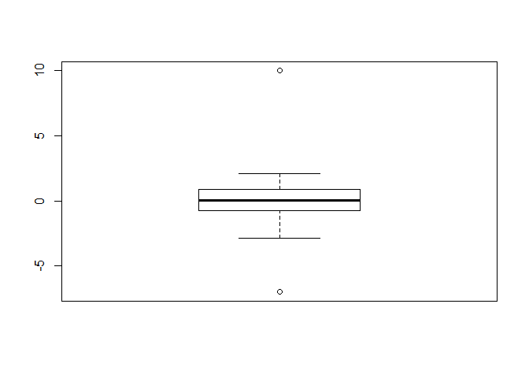

```r
 boxplot(x)
```

# 8 Sorting

- Use the `sort` function to sort the elements of an object:

```r
sort(x, partial = NULL, na.last = NA, decreasing = FALSE,
         method = c("auto", "shell", "quick", "radix"), index.return = FALSE)`
```

```r
w <- c(5, 4, 7, 2, 7, 1)
sort(w)
```

```
## [1] 1 2 4 5 7 7
```

```r
sort(w, decreasing = TRUE, index.return = T)
```

```
## $x
## [1] 7 7 5 4 2 1
##
## $ix
## [1] 3 5 1 2 4 6
```

- Control the treatment of *NA* values by setting the `na.last` argument:

```r
length(w) <- 8
w
```

```
## [1]  5  4  7  2  7  1 NA NA
```

```r
sort(w,na.last=TRUE)
```

```
## [1]  1  2  4  5  7  7 NA NA
```

```r
sort(w, decreasing = TRUE, na.last=FALSE)
```

```
## [1] NA NA  7  7  5  4  2  1
```

# 9 Package `dplyr`

- There is a powerful R package [‘dplyr’](https://cran.r-project.org/web/packages/dplyr/) for the data management.
- Usually, it has been installed, because many other packages depend on it.

## 9.1 `if_else`

Usage

```r
 if_else(condition, true, false, missing = NULL)
```

```r
 library(dplyr)
 x <- c(-5:5, NA)
 if_else(x < 0, NA_integer_, x)
```

```
##  [1] NA NA NA NA NA  0  1  2  3  4  5 NA
```

```r
 if_else(x < 0, "negative", "positive", "missing")
```

```
##  [1] "negative" "negative" "negative" "negative" "negative" "positive"
##  [7] "positive" "positive" "positive" "positive" "positive" "missing"
```

Unlike `ifelse`, `if_else` preserves types.

```r
 x <- factor(sample(letters[1:5], 10, replace = TRUE))
 x
```

```
##  [1] a c a a a c a e e e
## Levels: a c e
```

```r
 ifelse(x %in% c("a", "b", "c"), x, factor(NA))
```

```
##  [1]  1  2  1  1  1  2  1 NA NA NA
```

```r
 if_else(x %in% c("a", "b", "c"), x, factor(NA))
```

```
##  [1] a    c    a    a    a    c    a    <NA> <NA> <NA>
## Levels: a c e
```

```r
ifelse(rnorm(20)<0, 1, 0)
```

```
##  [1] 1 1 1 1 0 0 0 0 0 1 0 0 1 1 0 0 1 1 0 0
```

## 9.2 `lead` or `lag`

- Find the “next” or “previous” values in a vector. Useful for comparing values ahead of or behind the current values.

```r
 lead(1:10, 1)
```

```
##  [1]  2  3  4  5  6  7  8  9 10 NA
```

```r
 lead(1:10, 2)
```

```
##  [1]  3  4  5  6  7  8  9 10 NA NA
```

```r
 lag(1:10, 1)
```

```
##  [1] NA  1  2  3  4  5  6  7  8  9
```

```r
 lag(1:10, 2)
```

```
##  [1] NA NA  1  2  3  4  5  6  7  8
```

## 9.3 `case_when`

- This function allows you to vectorise multiple `if else()` statements. If no cases match, *NA* is returned.

```r
 x <- 1:50
 case_when( x %% 35 == 0 ~ "fizz buzz",
            x %% 5 == 0 ~ "fizz",
            x %% 7 == 0 ~ "buzz",
            TRUE ~ as.character(x) )
```

```
##  [1] "1"         "2"         "3"         "4"         "fizz"
##  [6] "6"         "buzz"      "8"         "9"         "fizz"
## [11] "11"        "12"        "13"        "buzz"      "fizz"
## [16] "16"        "17"        "18"        "19"        "fizz"
## [21] "buzz"      "22"        "23"        "24"        "fizz"
## [26] "26"        "27"        "buzz"      "29"        "fizz"
## [31] "31"        "32"        "33"        "34"        "fizz buzz"
## [36] "36"        "37"        "38"        "39"        "fizz"
## [41] "41"        "buzz"      "43"        "44"        "fizz"
## [46] "46"        "47"        "48"        "buzz"      "fizz"
```

If none of the cases match, NA is used:

```r
 case_when( x %% 35 == 0 ~ "fizz buzz",
            x %% 5 == 0 ~ "fizz",
            x %% 7 == 0 ~ "buzz")
```

```
##  [1] NA          NA          NA          NA          "fizz"
##  [6] NA          "buzz"      NA          NA          "fizz"
## [11] NA          NA          NA          "buzz"      "fizz"
## [16] NA          NA          NA          NA          "fizz"
## [21] "buzz"      NA          NA          NA          "fizz"
## [26] NA          NA          "buzz"      NA          "fizz"
## [31] NA          NA          NA          NA          "fizz buzz"
## [36] NA          NA          NA          NA          "fizz"
## [41] NA          "buzz"      NA          NA          "fizz"
## [46] NA          NA          NA          "buzz"      "fizz"
```

# 10 Exercises

- Ex1
  - Import data from “rawdata2.xlsx”, and save it as `foo.rda` or `foo.RData`.
  - Get the column names.
  - Get the row names, and replace space in each row name by underline symbol `_`, and vice versa.
- Ex2
  - Get the *mean*, *standard deviation*, *min*, *max*, *the first quantile*, *the third quantile*, and *median* of data from “rawdata2.xlsx”, columwise and rowwise, repectively.
  - Get the same values by using functions `apply()` and `sapply()`.

# 11 References

- Horton, N. and Kleinman, K., (2015). “*Using R and Rstudio*”. CRC Press.
- Kabacoff, R. I. . (2011). “*R in Action*”. Manning Publications Co.
- Baeza, S. . (2015). “*R For Beginners*.” CreateSpace Independent Publishing Platform.
- Adler, J. (2010). “*R in a nutshell: A desktop quick reference*”. O’Reilly Media, Inc.“.